# LA7 Data Betas

Drew Hoffman, Tanner Ball, Burke Parent, David Washburn, Brandon Nelsen

10/8/2019

```r
library(tidyverse)
library(lubridate)
Data <- read_delim(file = 'household_power_consumption.txt', delim = ';', na = c('?'), col_types = cols(
                    Date = col_date(format = "%d/%m/%Y"),
                    Time = col_time(format = "%H:%M:%S"),
                    Global_active_power = col_double(),
                    Global_reactive_power = col_double(),
                    Global_intensity = col_double(),
                    Sub_metering_1 = col_double(),
                    Sub_metering_2 = col_double(),
                    Sub_metering_3 = col_double()
                  ), locale = locale())
```

*Drew’s Plot*

Question: How does power consumption from the different sub-meters vary by days of the week?

We want to answer this question in order to determine if there certain days that may be more power heavy and provide opportunity to cut down on usage. By separating into submeters, it allows us to have a better idea of which appliances are contributing to the differences in the days.

I came up with this question after I discovered that there was a built in method for converting a date to its day of the week equivalent. I realized that day of the week must have a tangible effect on power usage.

The owner of this home would benefit from this analysis because it allows them to have a better idea of which days provide an opportunity to cut down on power usage. It may also help them manage their power draw as to not be drawing too much on any given day.

I handled missing data by removing NA values in the summarization. This meant that the counts for each day were not exactly equal, but the data set was so large that it had no effect.

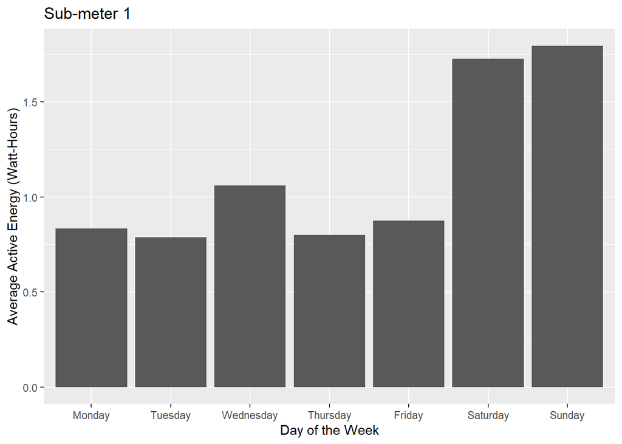

```r
library(dplyr)
custom = Data

#classifying by day of the week
custom$Date <- weekdays(as.Date(custom$Date))

#summarizing values for each sub meter
meter1 <- custom %>%
  group_by(Date) %>%
  summarise(count = n(), Sub_metering_1 = mean(Sub_metering_1, na.rm = T))
meter2 <- custom %>%
  group_by(Date) %>%
  summarise(count = n(), Sub_metering_2 = mean(Sub_metering_2, na.rm = T))
meter3 <- custom %>%
  group_by(Date) %>%
  summarise(count = n(), Sub_metering_3 = mean(Sub_metering_3, na.rm = T))

#totals by day
total <- custom %>%
  group_by(Date) %>%
  summarise(count = n(), Global_active_power = mean(Global_active_power, na.rm=T))

#creating data frame based on summarization
daysofweek <- c("Monday", "Tuesday", "Wednesday", "Thursday", "Friday", "Saturday", "Sunday")
meter1 <- c(0.8323669, 0.7863604, 1.0587722, 0.7995347, 0.8747174, 1.7264726, 1.7955411)
meter2 <- c(0.8782821, 1.3436162, 1.7343245, 0.7586387, 0.9980408, 1.4922046, 1.8957035)
meter3 <- c(6.224349, 6.412642, 6.384388, 6.030598, 6.759051, 7.492516, 5.914105)

df1 = data.frame(daysofweek, meter1)
df2 = data.frame(daysofweek, meter2)
df3 = data.frame(daysofweek, meter3)

ggplot(df1, aes(x = factor(daysofweek, level = c("Monday", "Tuesday", "Wednesday", "Thursday", "Friday", "Saturday", "Sunday")), y = meter1)) + geom_bar(stat = "identity") + xlab("Day of the Week") + ylab("Average Active Energy (Watt-Hours)") + ggtitle("Sub-meter 1")
```

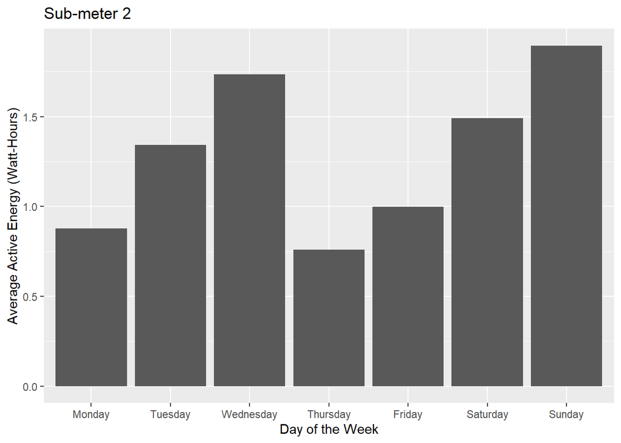

```r
ggplot(df2, aes(x = factor(daysofweek, level = c("Monday", "Tuesday", "Wednesday", "Thursday", "Friday", "Saturday", "Sunday")), y = meter2)) + geom_bar(stat = "identity") + xlab("Day of the Week") + ylab("Average Active Energy (Watt-Hours)") + ggtitle("Sub-meter 2")
```

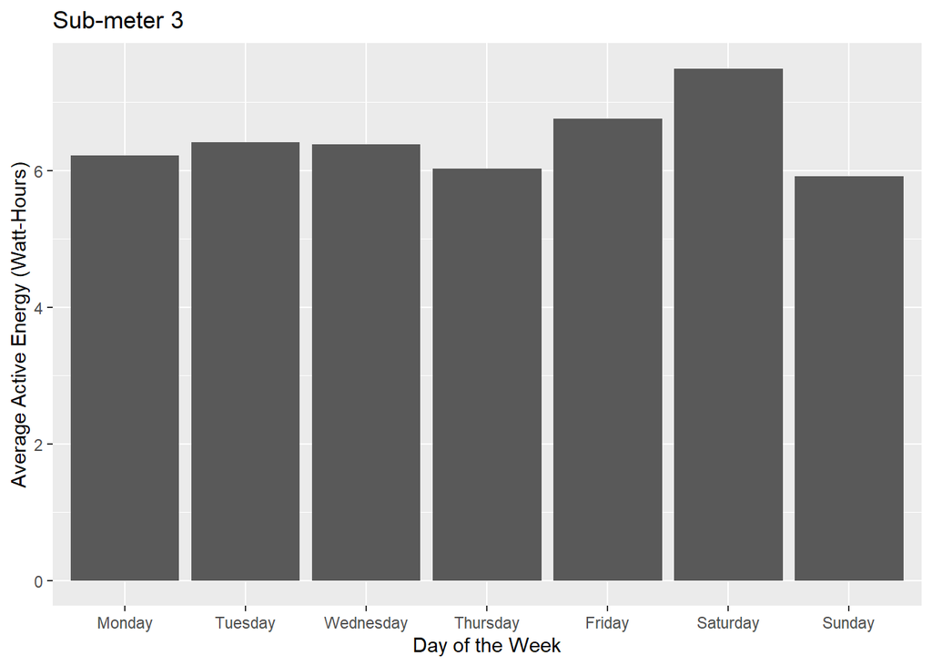

```r
ggplot(df3, aes(x = factor(daysofweek, level = c("Monday", "Tuesday", "Wednesday", "Thursday", "Friday", "Saturday", "Sunday")), y = meter3)) + geom_bar(stat = "identity") + xlab("Day of the Week") + ylab("Average Active Energy (Watt-Hours)") + ggtitle("Sub-meter 3")
```

*Tanner’s Plot*

Question: How does power consumption change over the course of a day?

We want to answer this question to see if there is any part of the day that is affecting the power bill more than others.

Answer: We can see that power consumption is by far the lowest during the earliest hours of the morning, and that power is consumed the most during the evening. While not a huge margin, there is a considerable difference between evening power consumption and the morning and afternoon consumption levels.

The homeowner can benefit from this analysis by considering how they are using the appliances in their house at different points in the day. If they can find a way to reduce usage of their appliances late in the day, they could lower their electric bill.

```r
library(stringr)

TimeGAP <- select(Data, "Time", "Global_active_power")

# Early Morning defined as the hours 12:00am-5:59am
earlyMorning <- filter(TimeGAP, str_detect(Time, "^00") | str_detect(Time, "^01") | str_detect(Time, "^02") | str_detect(Time, "^03") | str_detect(Time, "^04") | str_detect(Time, "^05"))

emAvg <- mean(earlyMorning$Global_active_power, na.rm=T)
# Avg early morning GAP = 0.503676666504025

# Morning defined as the hours 6:00am-11:59am
morning <- filter(TimeGAP, str_detect(Time, "^06") | str_detect(Time, "^07") | str_detect(Time, "^08") | str_detect(Time, "^09") | str_detect(Time, "^10") | str_detect(Time, "^11"))

mAvg <- mean(morning$Global_active_power, na.rm=T)
# Avg morning GAP = 1.2655260979185

# Afternoon defined as the hours 12:00pm-5:59pm (including noon for sake of equal intervals)
afternoon <- filter(TimeGAP, str_detect(Time, "^12") | str_detect(Time, "^13") | str_detect(Time, "^14") | str_detect(Time, "^15") | str_detect(Time, "^16") | str_detect(Time, "^17"))

aAvg <- mean(afternoon$Global_active_power, na.rm=T)
# Avg afternoon GAP = 1.07152755760981

# Evening defined as the hours 6:00pm-11:59pm
evening <- filter(TimeGAP, str_detect(Time, "^18") | str_detect(Time, "^19") | str_detect(Time, "^20") | str_detect(Time, "^21") | str_detect(Time, "^22") | str_detect(Time, "^23"))

eAvg <- mean(evening$Global_active_power, na.rm=T)
# Avg evening GAP = 1.52531286612387
```

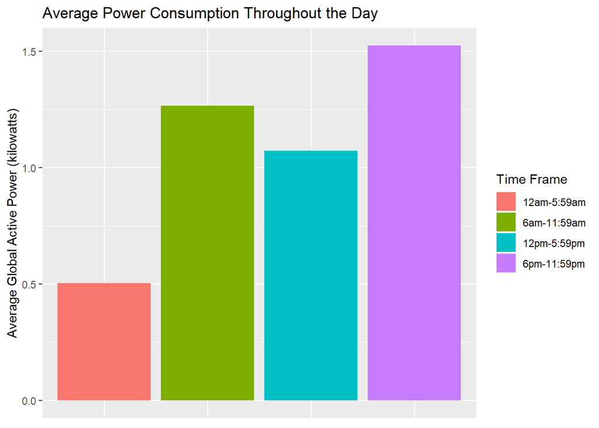

```r
library(ggplot2)

TimeFrame = c("12am-5:59am", "6am-11:59am", "12pm-5:59pm", "6pm-11:59pm")
GAPavg = c(emAvg, mAvg, aAvg, eAvg)
df = data.frame(TimeFrame, GAPavg)


df$TimeFrame <- factor(df$TimeFrame, levels=c("12am-5:59am", "6am-11:59am", "12pm-5:59pm", "6pm-11:59pm"))

ggplot(df, aes(x=TimeFrame, y=GAPavg, fill=TimeFrame)) + geom_col() + ggtitle("Average Power Consumption Throughout the Day") + labs(fill="Time Frame") + ylab("Average Global Active Power (kilowatts)") + theme(axis.title.x=element_blank(), axis.text.x=element_blank(), axis.ticks.x=element_blank())
```

*David’s Plot*

Question: How does energy consumption change throughout the seasons regarding the water heater and air conditioner?

We want to answer this question to see how different seasons could affect somebody’s power bill.

```r
library(lubridate)
library(ggplot2)
options(stringsAsFactors = FALSE)

#I only care about the water heater and air conditioner
SubMetering3 <-
  select(Data, "Date", "Sub_metering_3")

#Getting the Sub Metering value for spring
Spring <-
  filter(SubMetering3, Date >= as.Date("2006-03-01") & Date <= as.Date("2006-05-31") | Date >=   as.Date("2007-03-01") & Date <= as.Date("2007-05-31") | Date >= as.Date("2008-03-01") & Date <= as.Date("2008-05-31") | Date >= as.Date("2009-03-01") & Date <= as.Date("2009-05-31") | Date >= as.Date("2010-03-01") & Date <= as.Date("2010-05-31"))

SpSM3 <-
  sum(Spring$Sub_metering_3, na.rm = TRUE)

  # SpSM3 = 3547933

#Getting the Sub Metering value for summer
Summer <-
  filter(SubMetering3, Date >= as.Date("2006-06-01") & Date <= as.Date("2006-08-31") | Date >=   as.Date("2007-06-01") & Date <= as.Date("2007-08-31") | Date >= as.Date("2008-08-01") & Date <= as.Date("2008-08-31") | Date >= as.Date("2009-06-01") & Date <= as.Date("2009-08-31") | Date >= as.Date("2010-06-01") & Date <= as.Date("2010-08-31"))

SuSM3 <-
  sum(Summer$Sub_metering_3, na.rm = TRUE)

  #SuSM3 = 1948777

#Getting the Sub Metering value for Fall
Fall <-
  filter(SubMetering3, Date >= as.Date("2006-09-01") & Date <= as.Date("2006-11-30") | Date >=   as.Date("2007-09-01") & Date <= as.Date("2007-11-30") | Date >= as.Date("2008-09-01") & Date <= as.Date("2008-11-30") | Date >= as.Date("2009-09-01") & Date <= as.Date("2009-11-30") | Date >= as.Date("2010-09-01") & Date <= as.Date("2010-11-30"))

FaSM3 <-
  sum(Fall$Sub_metering_3, na.rm = TRUE)

  #FaSM3 = 3403153

#Getting the Sub Metering value for Winter
Winter <-
  filter(SubMetering3, Date >= as.Date("2006-12-01") & Date <= as.Date("2007-02-28") | Date >=   as.Date("2007-12-01") & Date <= as.Date("2008-02-28") | Date >= as.Date("2008-12-01") & Date <= as.Date("2009-02-28") | Date >= as.Date("2009-12-01") & Date <= as.Date("2010-02-28") | Date >= as.Date("2010-12-01") & Date <= as.Date("2011-02-28"))

WiSM3 <-
  sum(Winter$Sub_metering_3, na.rm = TRUE)

  # WiSM3 = 3809911

#Create a new data frame with the values for each season

Season = c("Spring", "Summer", "Fall", "Winter")
Value = c(3547933, 1948777, 3403153, 3809911)

df = data.frame(Season, Value)
head(df)
```

```
##   Season   Value
## 1 Spring 3547933
## 2 Summer 1948777
## 3   Fall 3403153
## 4 Winter 3809911
```

[figure not shown]

```r
#Create a pie chart to compare sub metering between seasons
bp<- ggplot(df, aes(x="", y=Value, fill=Season))+
geom_bar(width = 1, stat = "identity")+
  xlab('')+
  ylab('')+
  ggtitle("Water Heater and Air Conditioning Usage
(Measured in watt-hour of active energy)")

pie <- bp + coord_polar("y", start=0) +
    geom_text(aes(y = Value/2.4 + c(0, cumsum(Value)[-length(Value)]),
            label = (Value)), size=4.5) +
  theme(axis.text = element_blank(),
        axis.ticks = element_blank(),
        panel.grid = element_blank())
pie
```

# *Brandon’s Plot*

Brandon:

Question: How is power effected on the largest holiday of the year in France, Bastille Day?

We want to see this question to determine if power usage on holidays could cause a spike in somebody’s power bill for the month.

This could benefit the home owner and others that decide to host a party on that day, that it could affect one’s electricity bill for the month and it helps electricity companies gauge how much power could be used on Bastille Day to make sure there are now brown or blackouts because more electricity could be used during this celebration.

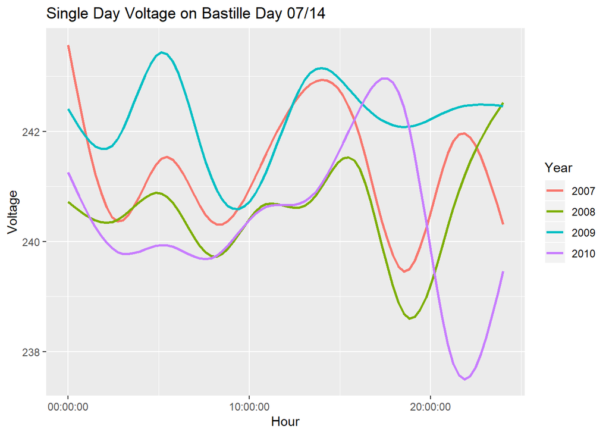

```r
Date_separation <- Data %>% mutate(year = substr(Date,1,4), month = substr(Date,6,7), day = substr(Date,9,10))
Bastille_Day <- Date_separation %>% filter(day == "14" & month == "07")

ggplot(Data = Bastille_Day) +
  geom_smooth(mapping = aes(x = Bastille_Day$Time, y = Bastille_Day$Voltage, color = Bastille_Day$year), se = FALSE)+
  xlab('Hour')+
  ylab('Voltage')+
  ggtitle('Single Day Voltage on Bastille Day 07/14')+
  labs(color = 'Year')
```

I dealt with missing Data by completely removing it from my data set, 2006 had no readings for July 14, so I just did the years 2007-2010 to look at my question.

I used Geom_smooth to graph my data after manipulating by separating date into substring and filtering it by month and day, July and 14.